# Project: Investigate a Dataset (No-Show appointments)

- Introduction
- Data Wrangling
- Exploratory Data Analysis
- Conclusions

## Introduction

No-show appointments Data which related the healthcare sectore so the Question are

Q1-How many people are in Bolsa Familia scholar shipe?

Q2-How many Males and Females are in the data set ?

Q3-How many people show-up appointment, what is the mean age of them and how many of them chornic diseases ( Diabetes , Hipertension) ?

Q4- How many people not show-up appointment, what is the mean age of them and how many of them chornic diseases ( Diabetes , Hipertension) ?

Q5-Is there a realation between Alcoholism and the show-up ?

Q6 Is the Handcap effect on the show-up ?

```python
# Use this cell to set up import statements for all of the packages that you
#   plan to use.
import pandas as pd
import numpy as np
import matplotlib.pyplot as plt
import re

# Remember to include a 'magic word' so that your visualizations are plotted
#   inline with the notebook. See this page for more:
#   http://ipython.readthedocs.io/en/stable/interactive/magics.html
```

## Data Wrangling

### General Properties

```python
# Load your data and print out a few lines. Perform operations to inspect data
#   types and look for instances of missing or possibly errant data.
df=pd.read_csv('E://Data Analysis//KaggleV2-May-2016.csv')
```

```python
# explore the dataset
df.info()
```

```
<class 'pandas.core.frame.DataFrame'>
RangeIndex: 110527 entries, 0 to 110526
Data columns (total 14 columns):
 #   Column          Non-Null Count   Dtype
---  ------          --------------   -----
 0   PatientId       110527 non-null  float64
 1   AppointmentID   110527 non-null  int64
 2   Gender          110527 non-null  object
 3   ScheduledDay    110527 non-null  object
 4   AppointmentDay  110527 non-null  object
 5   Age             110527 non-null  int64
 6   Neighbourhood   110527 non-null  object
 7   Scholarship     110527 non-null  int64
 8   Hipertension    110527 non-null  int64
 9   Diabetes        110527 non-null  int64
 10  Alcoholism      110527 non-null  int64
 11  Handcap         110527 non-null  int64
 12  SMS_received    110527 non-null  int64
 13  No-show         110527 non-null  object
dtypes: float64(1), int64(8), object(5)
memory usage: 11.8+ MB
```

```python
df.describe()
```

|  | PatientId | AppointmentID | Age | Scholarship | Hipertension | Diabetes | Alcoholism | Handcap | SMS_received |
| --- | --- | --- | --- | --- | --- | --- | --- | --- | --- |
| count | 1.105270e+05 | 1.105270e+05 | 110527.000000 | 110527.000000 | 110527.000000 | 110527.000000 | 110527.000000 | 110527.000000 | 110527.000000 |
| mean | 1.474963e+14 | 5.675305e+06 | 37.088874 | 0.098266 | 0.197246 | 0.071865 | 0.030400 | 0.022248 | 0.321026 |
| std | 2.560949e+14 | 7.129575e+04 | 23.110205 | 0.297675 | 0.397921 | 0.258265 | 0.171686 | 0.161543 | 0.466873 |
| min | 3.921784e+04 | 5.030230e+06 | -1.000000 | 0.000000 | 0.000000 | 0.000000 | 0.000000 | 0.000000 | 0.000000 |
| 25% | 4.172614e+12 | 5.640286e+06 | 18.000000 | 0.000000 | 0.000000 | 0.000000 | 0.000000 | 0.000000 | 0.000000 |
| 50% | 3.173184e+13 | 5.680573e+06 | 37.000000 | 0.000000 | 0.000000 | 0.000000 | 0.000000 | 0.000000 | 0.000000 |
| 75% | 9.439172e+13 | 5.725524e+06 | 55.000000 | 0.000000 | 0.000000 | 0.000000 | 0.000000 | 0.000000 | 1.000000 |
| max | 9.999816e+14 | 5.790484e+06 | 115.000000 | 1.000000 | 1.000000 | 1.000000 | 1.000000 | 4.000000 | 1.000000 |

```
array([[<matplotlib.axes._subplots.AxesSubplot object at 0x000000014B6DC6C8>,
      dtype=object)
```

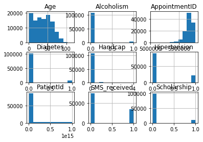

```python
df.hist()
```

# check the logical of data

check the if the Age is less than 0 and the patient whose age is 0 is the baby

```python
y=df.query('Age < 0')
y
```

|  | PatientId | AppointmentID | Gender | ScheduledDay | AppointmentDay | Age | Neighbourhood | Scholarship | Hipertension | Diabetes | Alcoholism | Handcap | SMS_received | No-show |
| --- | --- | --- | --- | --- | --- | --- | --- | --- | --- | --- | --- | --- | --- | --- |
| 99832 | 4.659432e+14 | 5775010 | F | 2016-06-06T08:58:13Z | 2016-06-06T00:00:00Z | -1 | ROMÃO | 0 | 0 | 0 | 0 | 0 | 0 | No |

```python
#so we delete this row
df=df.drop(index=99832)
```

```python
# split the dataset to analyze each part
#and find the effect the all attributes on the No show variable
df_yes= df[df['No-show'] == 'Yes']
df_no= df[df['No-show'] == 'No']
```

## explore each part

```python
df_no.describe()
```

|  | PatientId | AppointmentID | Age | Scholarship | Hipertension | Diabetes | Alcoholism | Handcap | SMS_received |
| --- | --- | --- | --- | --- | --- | --- | --- | --- | --- |
| count | 8.820700e+04 | 8.820700e+04 | 88207.000000 | 88207.000000 | 88207.000000 | 88207.000000 | 88207.000000 | 88207.000000 | 88207.000000 |
| mean | 1.476809e+14 | 5.681135e+06 | 37.790504 | 0.093904 | 0.204394 | 0.073838 | 0.030417 | 0.022742 | 0.291337 |
| std | 2.563739e+14 | 6.931193e+04 | 23.338645 | 0.291697 | 0.403261 | 0.261508 | 0.171733 | 0.162751 | 0.454381 |
| min | 3.921784e+04 | 5.030230e+06 | 0.000000 | 0.000000 | 0.000000 | 0.000000 | 0.000000 | 0.000000 | 0.000000 |
| 25% | 4.168386e+12 | 5.646218e+06 | 18.000000 | 0.000000 | 0.000000 | 0.000000 | 0.000000 | 0.000000 | 0.000000 |
| 50% | 3.176138e+13 | 5.685683e+06 | 38.000000 | 0.000000 | 0.000000 | 0.000000 | 0.000000 | 0.000000 | 0.000000 |
| 75% | 9.433684e+13 | 5.731078e+06 | 56.000000 | 0.000000 | 0.000000 | 0.000000 | 0.000000 | 0.000000 | 1.000000 |
| max | 9.999816e+14 | 5.790484e+06 | 115.000000 | 1.000000 | 1.000000 | 1.000000 | 1.000000 | 4.000000 | 1.000000 |

```python
df_yes.info()
```

```
<class 'pandas.core.frame.DataFrame'>
Int64Index: 22319 entries, 6 to 110516
Data columns (total 14 columns):
 #   Column          Non-Null Count  Dtype
---  ------          --------------  -----
 0   PatientId       22319 non-null  float64
 1   AppointmentID   22319 non-null  int64
 2   Gender          22319 non-null  object
 3   ScheduledDay    22319 non-null  object
 4   AppointmentDay  22319 non-null  object
 5   Age             22319 non-null  int64
 6   Neighbourhood   22319 non-null  object
 7   Scholarship     22319 non-null  int64
 8   Hipertension    22319 non-null  int64
 9   Diabetes        22319 non-null  int64
 10  Alcoholism      22319 non-null  int64
 11  Handcap         22319 non-null  int64
 12  SMS_received    22319 non-null  int64
 13  No-show         22319 non-null  object
dtypes: float64(1), int64(8), object(5)
memory usage: 2.6+ MB
```

### Data Cleaning (convert some attributes to other data type )

```python
# convert AppointmentDay of two data frame to datetime type
df_no['AppointmentDay']=pd.to_datetime(df_no['AppointmentDay'])
df_yes['AppointmentDay']=pd.to_datetime(df_yes['AppointmentDay'])
```

[output not shown]

```python
# convert the ScheduledDay of both dataframe to datetime type
df_yes['ScheduledDay']=pd.to_datetime(df_yes['ScheduledDay'])
df_no['ScheduledDay']=pd.to_datetime(df_no['ScheduledDay'])
```

[output not shown]

```python
# check the change of the data type
df_no.info()
df_yes.info()
```

```
<class 'pandas.core.frame.DataFrame'>
Int64Index: 88207 entries, 0 to 110526
Data columns (total 14 columns):
 #   Column          Non-Null Count  Dtype
---  ------          --------------  -----
 0   PatientId       88207 non-null  float64
 1   AppointmentID   88207 non-null  int64
 2   Gender          88207 non-null  object
 3   ScheduledDay    88207 non-null  datetime64[ns, UTC]
 4   AppointmentDay  88207 non-null  datetime64[ns, UTC]
 5   Age             88207 non-null  int64
 6   Neighbourhood   88207 non-null  object
 7   Scholarship     88207 non-null  int64
 8   Hipertension    88207 non-null  int64
 9   Diabetes        88207 non-null  int64
 10  Alcoholism      88207 non-null  int64
 11  Handcap         88207 non-null  int64
 12  SMS_received    88207 non-null  int64
 13  No-show         88207 non-null  object
dtypes: datetime64[ns, UTC](2), float64(1), int64(8), object(3)
memory usage: 10.1+ MB
<class 'pandas.core.frame.DataFrame'>
Int64Index: 22319 entries, 6 to 110516
Data columns (total 14 columns):
 #   Column          Non-Null Count  Dtype
---  ------          --------------  -----
 0   PatientId       22319 non-null  float64
 1   AppointmentID   22319 non-null  int64
 2   Gender          22319 non-null  object
 3   ScheduledDay    22319 non-null  datetime64[ns, UTC]
 4   AppointmentDay  22319 non-null  datetime64[ns, UTC]
 5   Age             22319 non-null  int64
 6   Neighbourhood   22319 non-null  object
 7   Scholarship     22319 non-null  int64
 8   Hipertension    22319 non-null  int64
 9   Diabetes        22319 non-null  int64
 10  Alcoholism      22319 non-null  int64
 11  Handcap         22319 non-null  int64
 12  SMS_received    22319 non-null  int64
 13  No-show         22319 non-null  object
dtypes: datetime64[ns, UTC](2), float64(1), int64(8), object(3)
memory usage: 2.6+ MB
```

```python
# remove any characters from Neighbourhood
df_yes['Neighbourhood']=df_yes['Neighbourhood'].map(lambda x: re.sub(r'\W+', '', x))
df_no['Neighbourhood']=df_no['Neighbourhood'].map(lambda x: re.sub(r'\W+', '', x))
```

[output not shown]

```python
#check the age validate and i assume the patient with age =0 is baby
z=df_no.query('Age < 0')
z
```

|  | PatientId | AppointmentID | Gender | ScheduledDay | AppointmentDay | Age | Neighbourhood | Scholarship | Hipertension | Diabetes | Alcoholism | Handcap | SMS_received | No-show |
| --- | --- | --- | --- | --- | --- | --- | --- | --- | --- | --- | --- | --- | --- | --- |

```python
#check the age
y=df_yes.query('Age < 0')
y
```

|  | PatientId | AppointmentID | Gender | ScheduledDay | AppointmentDay | Age | Neighbourhood | Scholarship | Hipertension | Diabetes | Alcoholism | Handcap | SMS_received | No-show |
| --- | --- | --- | --- | --- | --- | --- | --- | --- | --- | --- | --- | --- | --- | --- |